# Bottleneck

Emily, Bihan, Linping

6/21/2018

## Operational Bottleneck Analysis:

In our analysis, we calculate hourly total number of physicians and total number of patient per hour.

Patient Output Number:

- The number of patient output is defined by calculating how many patients encountered the event `Patient transferred to Checkout`.

Physician Number Calculation:

- Group by the name of physician and date.
- For a particular physician, we find out the time of both first and last show up time.
- Calculate the census of all physician: the number of physicians working within each hour.

The assumption of the calculation:

- Physician do not leave the hospital early in the day, and return late in the same day (i.e. go home at 1am and back to work at 11pm)
- During the time period between fist and last show up time, the physician was working.

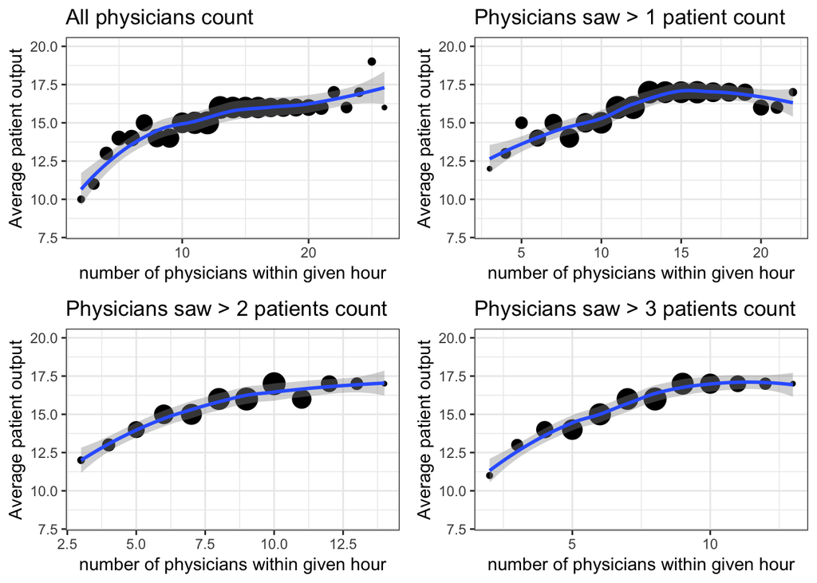

From above plots, as the number of physicians increases, the average patient output increases as well until number of physicians reach to 10. When there are more than 10 physicians working in peak hours, it will not increase number of patients get out of ED. Therefore, based on our analysis, during peak hour (from 6pm to midnight), 10 physicians will be enought.